# Lab 4: Smoking and Low Birth Weight?

#### Ping

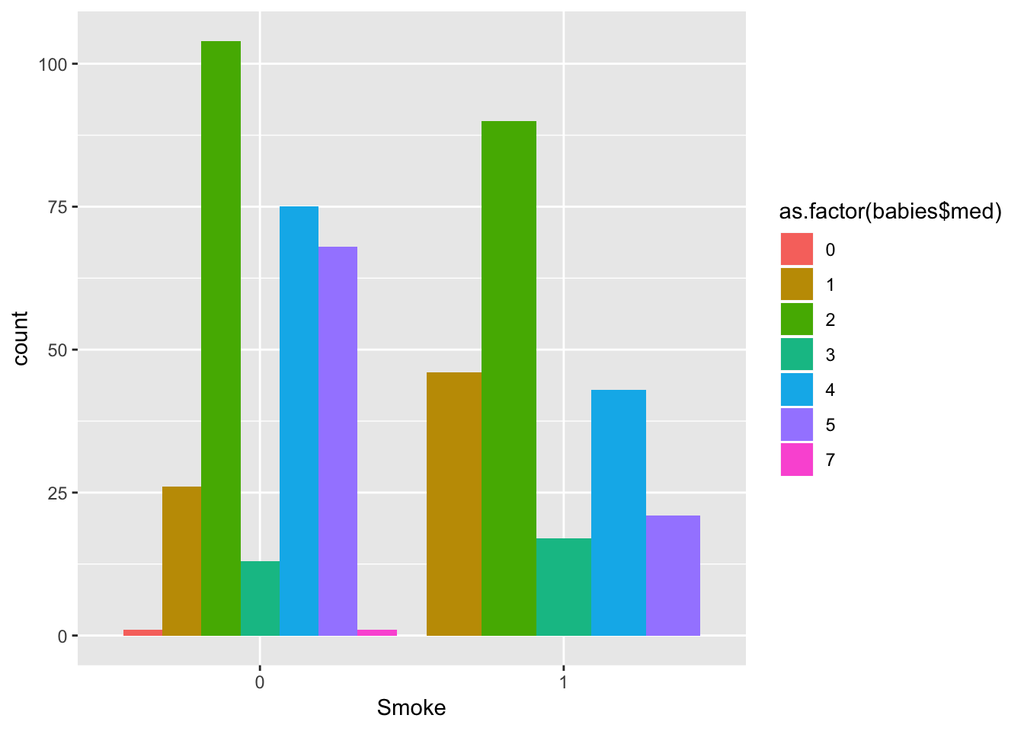

```r
babies <- na.omit(babies)
ggplot(data = babies) +  geom_bar(mapping = aes(x = as.factor(babies$smoke), fill = as.factor(babies$med)), position = "dodge") + labs(x = "Smoke")
```

I started by analyzing what variables are different between women who smoke or not. From the graph, we can see, women who never smoked, generally have higher education. Women who smoked have higher counts of pre-high school education. Women who didn’t smoke have higher counts of high school education, some colleges education, and college graduate.

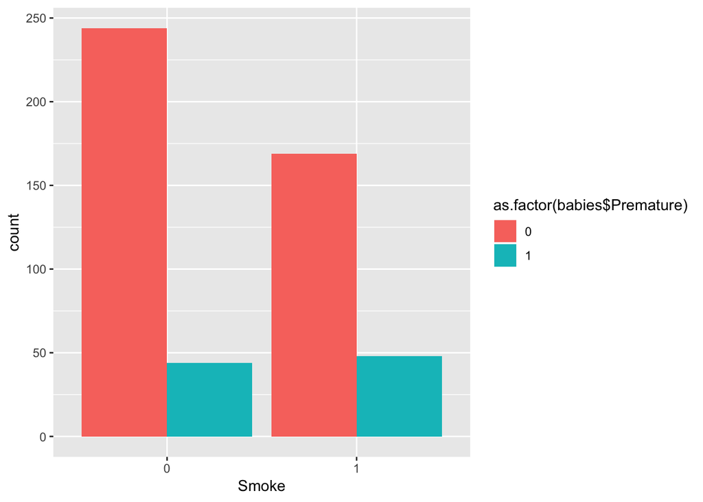

```r
babies <- na.omit(babies)
ggplot(data = babies) +
  geom_bar(mapping = aes(x = as.factor(babies$smoke), fill = as.factor(babies$Premature)), position = "dodge") + labs(x = "Smoke")
```

From the graph, we can see the counts of mom who smoke and have premature babies are slightly higher than the babies’ mom who don’t smoke. So the Surgeon General’s first assertion is right.

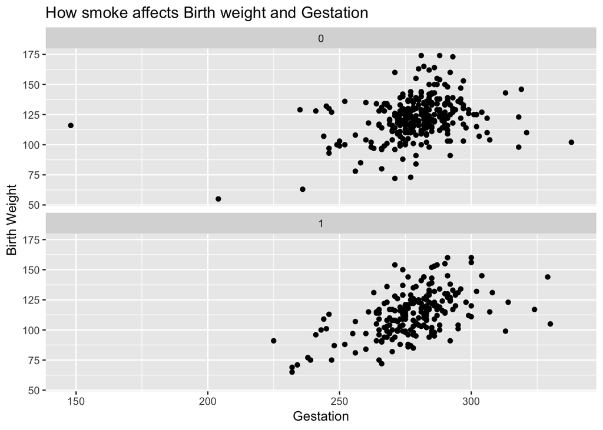

```r
ggplot(data = babies) +
  geom_point(mapping = aes(x = babies$gestation, y = babies$bwtoz))+
  facet_wrap(~babies$smoke, nrow = 2) + labs(x = "Gestation", y = "Birth Weight") + ggtitle("How smoke affects Birth weight and Gestation")
```

From the graph below, we can see that mom who don’t smoke, it is denser for babies to have higher birth weight and longer gestation.